# Telco Customer Churn

Dustin Shook

2023-07-11

# Objectives

Explore Telco customer churn with a data set from [Kaggle](https://www.kaggle.com/datasets/blastchar/telco-customer-churn)

- Data Manipulation: `dplyr`, `tidyr`, and `tibble`
- EDA & visualizations: `skimr` and `ggplot`
- Customer Segmentation with `kmeans()` and `umap()`
- Modeling: `tidymodels` framework.

# Data Definitions

```r
data_def_reactable(data_def, raw_data)
```

| Column | Definition |
| --- | --- |
| customerID | unique customer id |
| gender | male or female |
| SeniorCitizen | senior citizen (Yes or No) |
| Partner | customer has a domestic partner (Yes or No) |
| Dependents | customer has domestic dependents (Yes or No) |
| PhoneService | customer phone service (Yes or No) |
| MultipleLines | customer multiple lines (Yes or No) |
| InternetService | customer internet service (DSL, Fiber optic, No) |
| OnlineSecurity | customer has online security (Yes, No, No internet service) |
| OnlineBackup | customer has online backup (Yes, No, No internet service) |

[output cut: 11 more lines]

# Exploratory Data Analysis

## Step 1 - Initial look

We’ll start by using the [`skimr`](https://docs.ropensci.org/skimr/) package to get a feel for our data. This data set is pretty clean and shouldn’t require a ton of cleansing.

```r
skimr::skim(raw_data)
```

Data summary

| Name | raw_data |
| --- | --- |
| Number of rows | 7043 |
| Number of columns | 21 |
| _______________________ |  |
| Column type frequency: |  |
| character | 18 |
| numeric | 3 |
| ________________________ |  |
| Group variables | None |

**Variable type: character**

| skim_variable | n_missing | complete_rate | min | max | empty | n_unique | whitespace |
| --- | --- | --- | --- | --- | --- | --- | --- |
| customerID | 0 | 1 | 10 | 10 | 0 | 7043 | 0 |
| gender | 0 | 1 | 4 | 6 | 0 | 2 | 0 |
| SeniorCitizen | 0 | 1 | 2 | 3 | 0 | 2 | 0 |
| Partner | 0 | 1 | 2 | 3 | 0 | 2 | 0 |
| Dependents | 0 | 1 | 2 | 3 | 0 | 2 | 0 |
| PhoneService | 0 | 1 | 2 | 3 | 0 | 2 | 0 |
| MultipleLines | 0 | 1 | 2 | 16 | 0 | 3 | 0 |
| InternetService | 0 | 1 | 2 | 11 | 0 | 3 | 0 |
| OnlineSecurity | 0 | 1 | 2 | 19 | 0 | 3 | 0 |
| OnlineBackup | 0 | 1 | 2 | 19 | 0 | 3 | 0 |
| DeviceProtection | 0 | 1 | 2 | 19 | 0 | 3 | 0 |
| TechSupport | 0 | 1 | 2 | 19 | 0 | 3 | 0 |
| StreamingTV | 0 | 1 | 2 | 19 | 0 | 3 | 0 |
| StreamingMovies | 0 | 1 | 2 | 19 | 0 | 3 | 0 |
| Contract | 0 | 1 | 8 | 14 | 0 | 3 | 0 |
| PaperlessBilling | 0 | 1 | 2 | 3 | 0 | 2 | 0 |
| PaymentMethod | 0 | 1 | 12 | 25 | 0 | 4 | 0 |
| Churn | 0 | 1 | 2 | 3 | 0 | 2 | 0 |

**Variable type: numeric**

| skim_variable | n_missing | complete_rate | mean | sd | p0 | p25 | p50 | p75 | p100 | hist |
| --- | --- | --- | --- | --- | --- | --- | --- | --- | --- | --- |
| tenure | 0 | 1 | 32.37 | 24.56 | 0.00 | 9.00 | 29.00 | 55.00 | 72.00 | ▇▃▃▃▆ |
| MonthlyCharges | 0 | 1 | 64.76 | 30.09 | 18.25 | 35.50 | 70.35 | 89.85 | 118.75 | ▇▅▆▇▅ |
| TotalCharges | 11 | 1 | 2283.30 | 2266.77 | 18.80 | 401.45 | 1397.47 | 3794.74 | 8684.80 | ▇▂▂▂▁ |

### Outcome Variable

Our target variable `Churn` is distributed reasonably and we don’t appear to have a large class imbalance to deal with.

```r
raw_data %>%
    count(Churn) %>%
    reactable()
```

| Churn | n |
| --- | --- |
| No | 5174 |
| Yes | 1869 |

## Step 2 - Numeric Variables

Let’s now turn our focus to the numeric predictors. We can use the package [`GGally`](https://ggobi.github.io/ggally/) to explore relationships in our data.

In the figure below, we can see that all of our numeric predictors `MonthlyCharges`, `TotalCharges` and `tenure` are correlated with each other with the highest correlation between `tenure` / `TotalCharges`

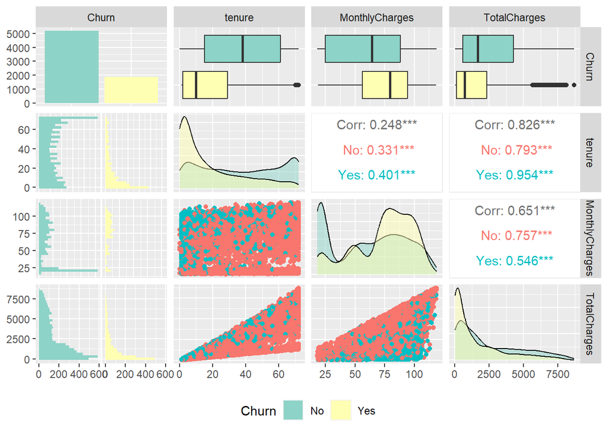

```r
raw_data %>%
    select(
        Churn,
        where(is.numeric),
        -SeniorCitizen # categorical variable, fixed later
    ) %>%
    ggpairs(
        aes(color = Churn),
        legend = 1,
        diag = list(continuous = wrap('densityDiag', alpha = .5))
    ) +
    theme(legend.position = "bottom") +
    scale_fill_brewer(palette = "Set3")
```

## Step 3 - Categorical Variables

Let’s take a closer look at our qualitative variables. First we’ll select our outcome variable `Churn` and all of our character columns. We also explicitly remove customer ID due to it being unique for every customer.

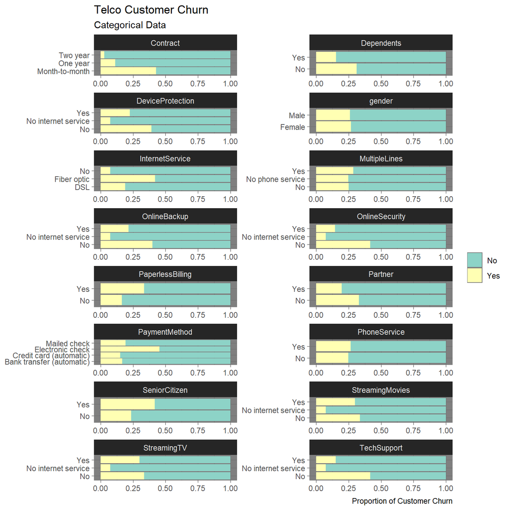

```r
raw_data %>%
    select(Churn, where(is.character), -customerID) %>%
    pivot_longer(!Churn) %>%
    ggplot(aes(y = value, fill = Churn)) +
    geom_bar(position = "fill") +
    facet_wrap(vars(name), scales = "free", ncol = 2) +
    labs(
        title = "Telco Customer Churn",
        subtitle = "Categorical Data",
        caption = "Proportion of Customer Churn",
        x = NULL,
        y = NULL,
        fill = NULL
    ) +
    scale_fill_brewer(palette = "Set3") +
    theme_dark()
```

### Minor adjustments

I notice that we have a rather redundant factor level `"No internet service"` with several of our categorical predictors. I decide to remove this level from all columns because it is already accounted for by the `InternetService` column. We’ll move forward from this point using our new `parsed_data` that contains the feature engineering we’ve added thus far.

```r
parsed_data <-
    raw_data %>%
    mutate(
        across(
            c(# re code the following categorical predictors
                DeviceProtection,
                OnlineBackup,
                StreamingTV,
                TechSupport,
                StreamingMovies,
                OnlineSecurity
                # if the factor level is 'no internet service' replace with a simple 'no'
            ), ~ if_else(.x == 'No internet service', 'No', .x)
        ),
        # do the same for the multi phone lines column for consistency
        MultipleLines = if_else(MultipleLines == 'No phone service', 'No', MultipleLines),
        # customers who have yet to make their first payment have a tenure of zero
        tenure = if_else(tenure == 0, 1, tenure),
        # these 0 tenure customers also have an NA for total charges
        # for our purposes we will assume everyone has made at least 1 monthly payment
        TotalCharges = if_else(is.na(TotalCharges), MonthlyCharges, TotalCharges)
    ) %>%
    relocate(where(is.numeric), .after = last_col())

reactable(parsed_data, wrap = F)
```

| customerID | gender | SeniorCitizen | Partner | Dependents | PhoneService | MultipleLines | InternetService | OnlineSecurity | OnlineBackup | DeviceProtection | TechSupport | StreamingTV | StreamingMovies | Contract | PaperlessBilling | PaymentMethod | Churn | tenure | MonthlyCharges | TotalCharges |
| --- | --- | --- | --- | --- | --- | --- | --- | --- | --- | --- | --- | --- | --- | --- | --- | --- | --- | --- | --- | --- |
| 7590-VHVEG | Female | No | Yes | No | No | No | DSL | No | Yes | No | No | No | No | Month-to-month | Yes | Electronic check | No | 1 | 29.85 | 29.85 |
| 5575-GNVDE | Male | No | No | No | Yes | No | DSL | Yes | No | Yes | No | No | No | One year | No | Mailed check | No | 34 | 56.95 | 1889.5 |
| 3668-QPYBK | Male | No | No | No | Yes | No | DSL | Yes | Yes | No | No | No | No | Month-to-month | Yes | Mailed check | Yes | 2 | 53.85 | 108.15 |
| 7795-CFOCW | Male | No | No | No | No | No | DSL | Yes | No | Yes | Yes | No | No | One year | No | Bank transfer (automatic) | No | 45 | 42.3 | 1840.75 |
| 9237-HQITU | Female | No | No | No | Yes | No | Fiber optic | No | No | No | No | No | No | Month-to-month | Yes | Electronic check | Yes | 2 | 70.7 | 151.65 |
| 9305-CDSKC | Female | No | No | No | Yes | Yes | Fiber optic | No | No | Yes | No | Yes | Yes | Month-to-month | Yes | Electronic check | Yes | 8 | 99.65 | 820.5 |
| 1452-KIOVK | Male | No | No | Yes | Yes | Yes | Fiber optic | No | Yes | No | No | Yes | No | Month-to-month | Yes | Credit card (automatic) | No | 22 | 89.1 | 1949.4 |
| 6713-OKOMC | Female | No | No | No | No | No | DSL | Yes | No | No | No | No | No | Month-to-month | No | Mailed check | No | 10 | 29.75 | 301.9 |
| 7892-POOKP | Female | No | Yes | No | Yes | Yes | Fiber optic | No | No | Yes | Yes | Yes | Yes | Month-to-month | Yes | Electronic check | Yes | 28 | 104.8 | 3046.05 |
| 6388-TABGU | Male | No | No | Yes | Yes | No | DSL | Yes | Yes | No | No | No | No | One year | No | Bank transfer (automatic) | No | 62 | 56.15 | 3487.95 |

[output cut: 7033 more lines]

### Second look

Let’s now take a second look at our categorical predictors visual, this time using `parsed_data` instead of our `raw_data`

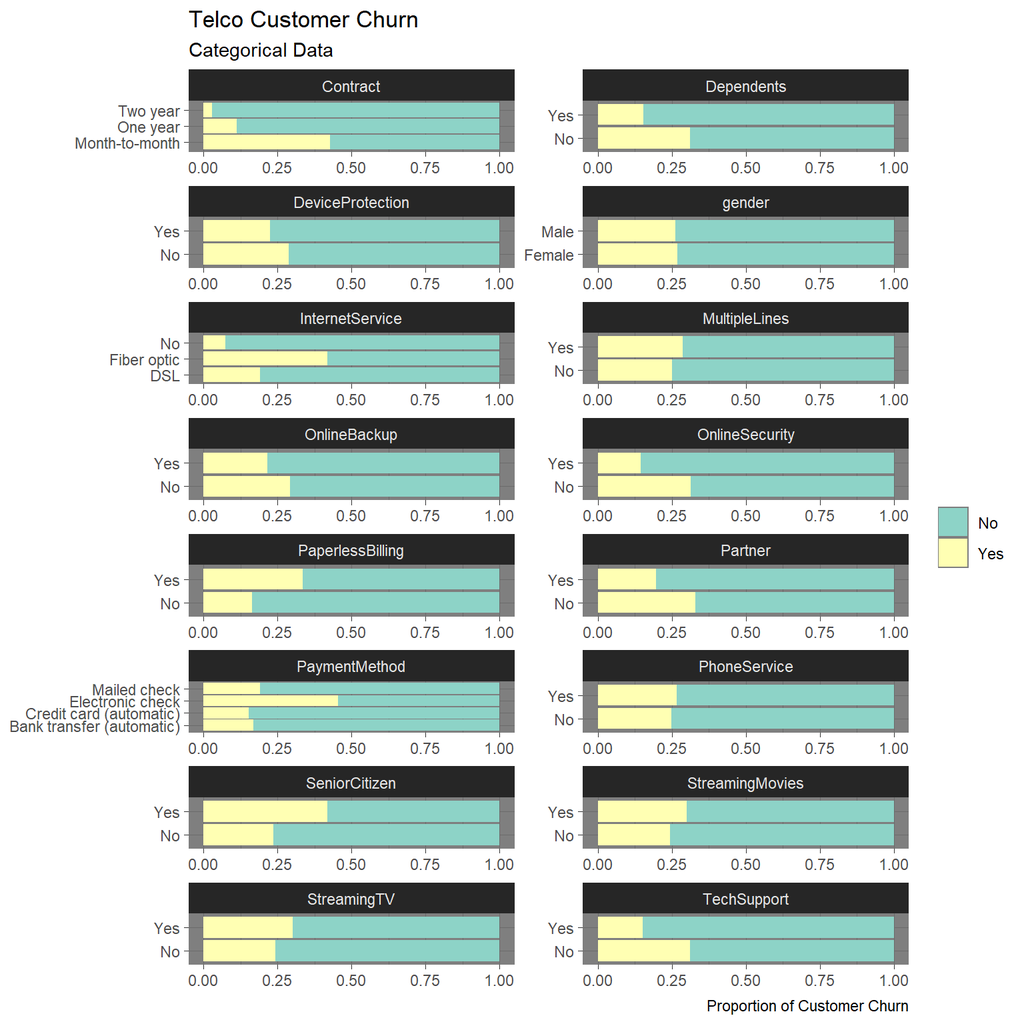

# Customer Segmentation

## Step 1 - Data preparation

- Drop our target variable `Churn`
- Center & Scale numeric columns
- Convert characters to factors
- Confirm `customerID` remains a character data type
- Convert factors to numeric

```r
kmeans_data <-
    parsed_data %>%
    select(-Churn) %>%
    mutate(
        across(where(is.numeric), ~ as.numeric(scale(.))),
        across(where(is.character), ~ as.factor(.)),
        customerID = as.character(customerID),
        across(where(is.factor), ~ as.numeric(.))
    )
```

## Step 2 - Generate UMAP 2D Projection

Next, with the data properly formatted we can generate a two dimensional representation from our many predictor variables.

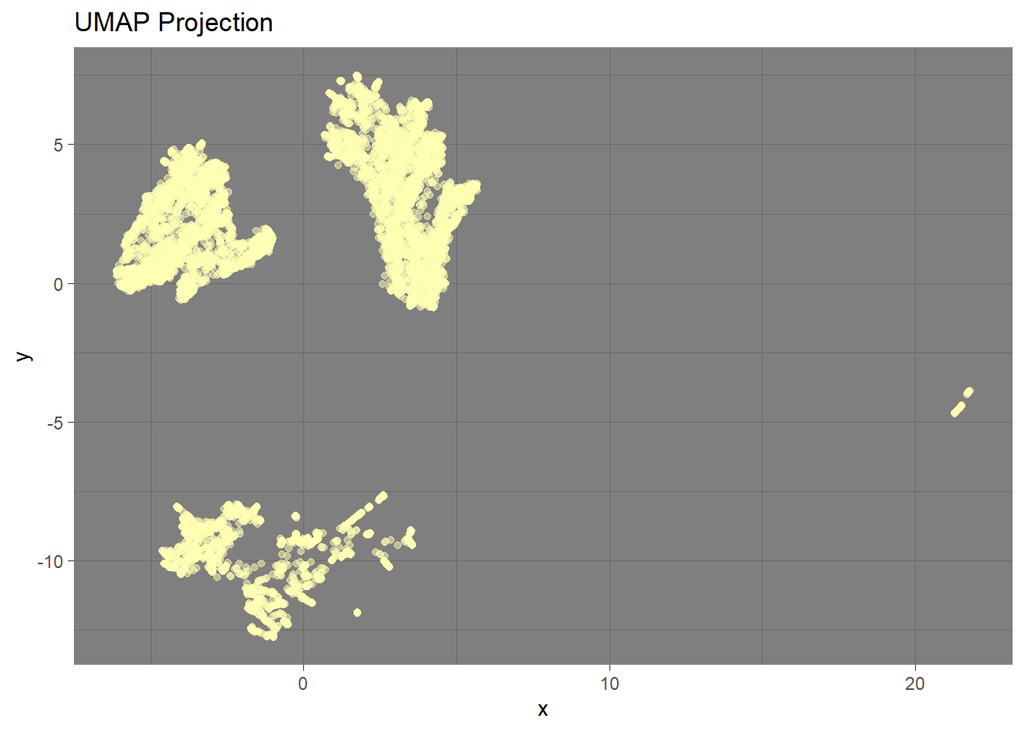

```r
library(umap)

churn_umap <-
    kmeans_data %>%
    select(-customerID) %>%
    umap()

churn_umap_tbl <-
    churn_umap %>%
    pluck("layout") %>%
    as_tibble(.name_repair = "unique") %>%
    set_names("x", "y") %>%
    bind_cols(
        select(parsed_data, customerID)
    )

churn_umap_tbl %>%
    ggplot(aes(x,y)) +
    geom_point(alpha = 0.5, color = '#FFFFB3') +
    labs(
        title = "UMAP Projection"
    ) +
    theme_dark()
```

## Step 3 - K-Means Clustering

Now we’ll turn our focus to `kmeans()` and choosing the correct value for k (centers). We’ll do this by creating a different cluster object for each value of k 2:7

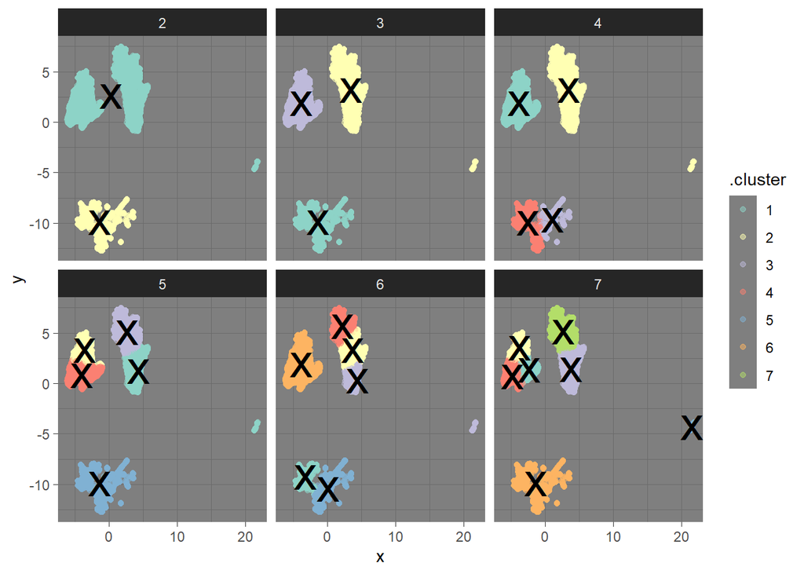

```r
cluster_analysis <-
    # create a tibble with values k 2:7
    tibble(k = 2:7) %>%
    # include k in call to row wise so that k is included in re frames
    rowwise(k) %>%
    mutate(
        clusters = list(
            kmeans( # remove customer Id column
                select(churn_umap_tbl, -customerID),
                centers = k
            )
        )
    )

tidy_clust <- cluster_analysis %>%
    reframe(
        tidy(clusters)
    )

glance_clust <- cluster_analysis %>%
    reframe(
        glance(clusters)
    )

augment_clust <- cluster_analysis %>%
    reframe(
        augment(clusters, churn_umap_tbl)
    )

augment_clust %>%
    ggplot(aes(x = x, y = y)) +
    geom_point(aes(color = .cluster), alpha = 0.5) +
    facet_wrap(~k) +
    geom_point(data = tidy_clust, size = 10, shape = "x") +
    scale_color_brewer(palette = "Set3") +
    theme_dark()
```

### Scree Plot

With the information we have thus far, 3 or 4 seems like the best value for k. Let’s try another approach with a Scree plot and see if we gain anymore insight.

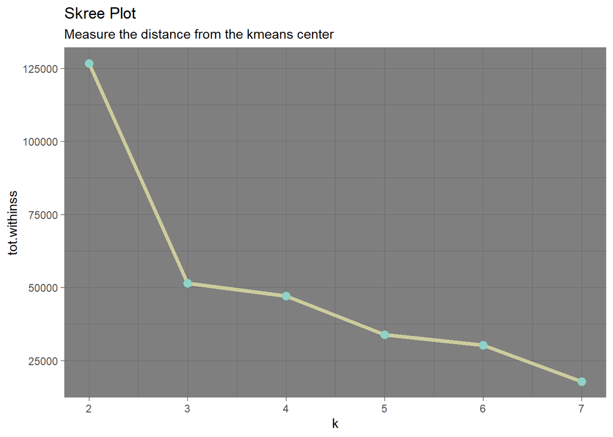

```r
glance_clust %>%
  ggplot(aes(k, tot.withinss)) +
  geom_line(alpha = 0.6, size = 1.5, color = "#FFFFB3") +
  geom_point(size = 3, color = "#8DD3C7") +
    labs(
        title = "Skree Plot",
        subtitle = "Measure the distance from the kmeans center"
    ) +
    theme_dark()
```

### Determine Best Value for K

Judging by our Scree plot the constant rate of change appears linear after `k = 3`, although one could argue that 4 may be the best solution.

```r
churn_clust_final <- kmeans(
    select(churn_umap_tbl, -customerID),
    centers = 3
)

glance(churn_clust_final)
```

```
## # A tibble: 1 × 4
##     totss tot.withinss betweenss  iter
##     <dbl>        <dbl>     <dbl> <int>
## 1 313126.       51418.   261708.     1
```

## Step 4 - Visualize Customer Segmentation

Let’s go back to our visualization and see if we can draw anymore insights now with the proper k value.

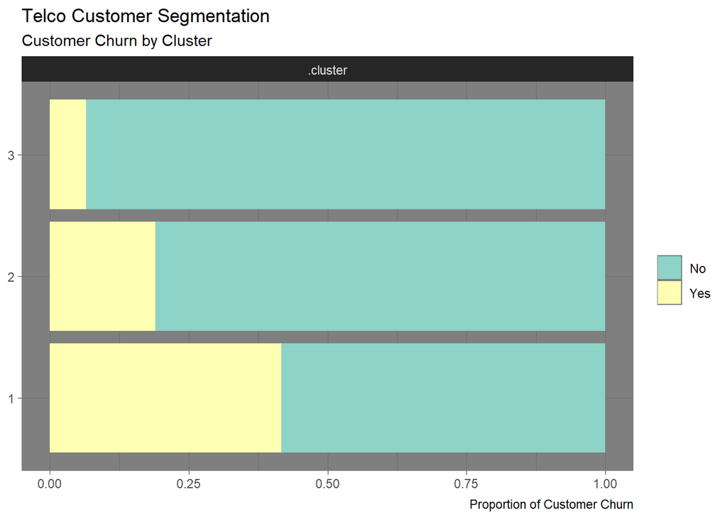

```r
augment(churn_clust_final, parsed_data) %>%
    select(Churn, .cluster) %>%
    pivot_longer(!Churn) %>%
    ggplot(aes(y = value, fill = Churn)) +
    geom_bar(position = "fill") +
    facet_wrap(vars(name), scales = "free", ncol = 2) +
    labs(
        title = "Telco Customer Segmentation",
        subtitle = "Customer Churn by Cluster",
        caption = "Proportion of Customer Churn",
        x = NULL,
        y = NULL,
        fill = NULL
    ) +
    scale_fill_brewer(palette = "Set3") +
    theme_dark()
```

# Model Building

## Step 1 - Data Prep

The majority of data preprocessing steps we will handle later using the [`recipes`](https://recipes.tidymodels.org/) package. For now, we’ll simply confirm that characters variables are converted to factors. We are going to use `customerID` as an ID variable instead of removing it, so we need to make sure it remains a character. Let’s also take one final `glimpse()` before we move on

```r
churn_df <-
    parsed_data %>%
    mutate(
        across(where(is.character), as.factor),
        customerID = as.character(customerID)
    )

glimpse(churn_df)
```

```
## Rows: 7,043
## Columns: 21
## $ customerID       <chr> "7590-VHVEG", "5575-GNVDE", "3668-QPYBK", "7795-CFOCW…
## $ gender           <fct> Female, Male, Male, Male, Female, Female, Male, Femal…
## $ SeniorCitizen    <fct> No, No, No, No, No, No, No, No, No, No, No, No, No, N…
## $ Partner          <fct> Yes, No, No, No, No, No, No, No, Yes, No, Yes, No, Ye…
## $ Dependents       <fct> No, No, No, No, No, No, Yes, No, No, Yes, Yes, No, No…
## $ PhoneService     <fct> No, Yes, Yes, No, Yes, Yes, Yes, No, Yes, Yes, Yes, Y…
## $ MultipleLines    <fct> No, No, No, No, No, Yes, Yes, No, Yes, No, No, No, Ye…
## $ InternetService  <fct> DSL, DSL, DSL, DSL, Fiber optic, Fiber optic, Fiber o…
## $ OnlineSecurity   <fct> No, Yes, Yes, Yes, No, No, No, Yes, No, Yes, Yes, No,…
## $ OnlineBackup     <fct> Yes, No, Yes, No, No, No, Yes, No, No, Yes, No, No, N…
## $ DeviceProtection <fct> No, Yes, No, Yes, No, Yes, No, No, Yes, No, No, No, Y…
## $ TechSupport      <fct> No, No, No, Yes, No, No, No, No, Yes, No, No, No, No,…
## $ StreamingTV      <fct> No, No, No, No, No, Yes, Yes, No, Yes, No, No, No, Ye…
## $ StreamingMovies  <fct> No, No, No, No, No, Yes, No, No, Yes, No, No, No, Yes…
## $ Contract         <fct> Month-to-month, One year, Month-to-month, One year, M…
## $ PaperlessBilling <fct> Yes, No, Yes, No, Yes, Yes, Yes, No, Yes, No, Yes, No…
## $ PaymentMethod    <fct> Electronic check, Mailed check, Mailed check, Bank tr…
## $ Churn            <fct> No, No, Yes, No, Yes, Yes, No, No, Yes, No, No, No, N…
## $ tenure           <dbl> 1, 34, 2, 45, 2, 8, 22, 10, 28, 62, 13, 16, 58, 49, 2…
## $ MonthlyCharges   <dbl> 29.85, 56.95, 53.85, 42.30, 70.70, 99.65, 89.10, 29.7…
## $ TotalCharges     <dbl> 29.85, 1889.50, 108.15, 1840.75, 151.65, 820.50, 1949…
```

### Training & Testing Split

It’s time to split our data into our training and testing sets. For good measure, we are also going to stratify our randomly sampled data sets by `Churn`.

```r
set.seed(1234)
churn_split <- initial_split(churn_df, strata = Churn)
churn_train <- training(churn_split)
churn_test <- testing(churn_split)
```

### 10-Fold Cross Validation

We also set up our cross-validation sets with the same stratification.

```r
set.seed(567)
churn_folds <- vfold_cv(churn_train, strata = Churn)
```

### Model Specification

Instead of deciding on a single model ourselves, instead we’ll utilize the [`tidymodels`](https://www.tidymodels.org/) frame-work to screen many different model types.

Notice we are specifying some of the model parameters as `tune()` instead of a static value. This tags the parameter to be optimized later.

```r
library(discrim)
library(parsnip)

mars_spec <-
    discrim_flexible(
        prod_degree = tune()
    ) %>%
    set_engine("earth")

glm_spec <-
     logistic_reg(
        penalty = tune(),
        mixture = tune()
    ) %>%
    set_engine("glmnet") %>%
    set_mode("classification")

knn_spec <-
   nearest_neighbor(
       neighbors = tune(),
       dist_power = tune(),
       weight_func = tune()
   ) %>%
   set_engine("kknn") %>%
   set_mode("classification")


svm_spec <-
    svm_rbf(
        cost = tune(),
        rbf_sigma = tune(),
        margin = tune()
    ) %>%
    set_engine("kernlab") %>%
    set_mode("classification")

rf_spec <-
   rand_forest(
       mtry = tune(),
       min_n = tune(),
       trees = 1000
   ) %>%
   set_engine("ranger") %>%
   set_mode("classification")

xgb_spec <-
    boost_tree(
        trees = tune(),
        min_n = tune(),
        mtry = tune(),
        learn_rate = 0.01
    ) %>%
    set_engine("xgboost") %>%
    set_mode("classification")
```

## Step 3 - Data Pre-Processing w/ Recipes

As mentioned previously, the bulk of our preprocessing steps are handled using [`recipes`](https://recipes.tidymodels.org/), below is a brief overview of the functions we’ll use to process our data.

- `update_role()` `customerID` column is only for ID purposes and will not be included
- `step_dummy()` Convert factor columns to binary
- `step_YeoJohnson()` normalize distribution
- `step_normalize()` Center and scale numeric columns
- `step_poly()` creates new predictors using orthogonal polynomials.

We’ll create 3 different recipe objects, each with varying levels of preprocessing steps. This will allow us to cater towards the requirements of each potential candidate model.

- `churn_recipe_base` minimal, we establish our outcome variable and convert our factor columns
- `churn_recipe_norm` normalize, center, and scale our predictors
- `churn_recipe_poly` transform our numeric predictors to add stability and avoid multicollinearity

```r
# minimal pre_proc
churn_recipe_base <-
    recipe(Churn ~ ., data = churn_train) %>%
    update_role(customerID, new_role = 'id') %>%
    step_dummy(all_nominal_predictors())

# normalization
churn_recipe_norm <-
    churn_recipe_base %>%
    step_YeoJohnson(all_numeric_predictors()) %>%
    step_normalize(all_numeric_predictors())

# quadratic
churn_recipe_poly <-
    churn_recipe_norm %>%
    step_poly(tenure, MonthlyCharges, TotalCharges)
```

### Workflow sets

Next, we’ll utilize the [`workflowsets`](https://workflowsets.tidymodels.org/reference/index.html) package to help us combine our candidate models with the appropriate recipes and preprocessors.

```r
minimal_pre_proc <-
    workflow_set(
        preproc = list(
            base_recipe = churn_recipe_base # minimal pre_proc
        ),
        models = list(
            MARS = mars_spec, # Multivariate Adaptive Regression Splines (MARS)
            RF   = rf_spec,   # Random Forest
            XGB  = xgb_spec   # XGBoost
        )
    )

poly_pre_proc <-
    workflow_set(
        preproc = list(
            quad = churn_recipe_poly # quadratic
        ),
        models = list(
            GLM = glm_spec, # GLM
            KNN = knn_spec  # k-nearest neighbors
        )
    )

normalized_pre_proc <-
    workflow_set(
        preproc = list(
            normal = churn_recipe_norm # normalization
        ),
        models = list(
            SVM = svm_spec, # support vector machine
            KNN = knn_spec, # k-nearest neighbors
            GLM = glm_spec  # GLM
        )
    )

all_workflows <-
    bind_rows( # combine them all into a single workflows object
        minimal_pre_proc,
        poly_pre_proc,
        normalized_pre_proc
    )


all_workflows
```

```
## # A tibble: 8 × 4
##   wflow_id         info             option    result
##   <chr>            <list>           <list>    <list>
## 1 base_recipe_MARS <tibble [1 × 4]> <opts[0]> <list [0]>
## 2 base_recipe_RF   <tibble [1 × 4]> <opts[0]> <list [0]>
## 3 base_recipe_XGB  <tibble [1 × 4]> <opts[0]> <list [0]>
## 4 quad_GLM         <tibble [1 × 4]> <opts[0]> <list [0]>
## 5 quad_KNN         <tibble [1 × 4]> <opts[0]> <list [0]>
## 6 normal_SVM       <tibble [1 × 4]> <opts[0]> <list [0]>
## 7 normal_KNN       <tibble [1 × 4]> <opts[0]> <list [0]>
## 8 normal_GLM       <tibble [1 × 4]> <opts[0]> <list [0]>
```

## Step 4 - Fine Tune Model Parameters

During our model specification, we established model parameters with the `tune()` argument instead of setting a static value. We’ll use racing methods from the `finetune` package to optimize these values.

[`tune_race_anova()`](https://finetune.tidymodels.org/reference/tune_race_anova.html) from the `finetune` package will eliminate combinations of different tuned model parameters that are not performing well using an `ANOVA` model. This will leave us with the best performing values as our final model parameters.

```r
library(finetune)
library(workflowsets)
library(doParallel)
library(tictoc)

cl <- makePSOCKcluster(
    detectCores(logical = T) - 2
)

registerDoParallel(cl)

race_control <-
    control_race(
        save_pred = TRUE,
        parallel_over = "everything",
        save_workflow = TRUE
    )

race_results <-
    all_workflows %>%
    workflow_map(
        "tune_race_anova",
        seed = 1345,
        resamples = churn_folds,
        grid = 25,
        metrics = metric_set(roc_auc),
        control = race_control
    )

race_results
```

```
## # A tibble: 8 × 4
##   wflow_id         info             option    result
##   <chr>            <list>           <list>    <list>
## 1 base_recipe_MARS <tibble [1 × 4]> <opts[4]> <race[+]>
## 2 base_recipe_RF   <tibble [1 × 4]> <opts[4]> <race[+]>
## 3 base_recipe_XGB  <tibble [1 × 4]> <opts[4]> <race[+]>
## 4 quad_GLM         <tibble [1 × 4]> <opts[4]> <race[+]>
## 5 quad_KNN         <tibble [1 × 4]> <opts[4]> <race[+]>
## 6 normal_SVM       <tibble [1 × 4]> <opts[4]> <race[+]>
## 7 normal_KNN       <tibble [1 × 4]> <opts[4]> <race[+]>
## 8 normal_GLM       <tibble [1 × 4]> <opts[4]> <race[+]>
```

## Step 5 - Evaluate results

The convenience function `autoplot` will help us visualize our best performing model from each workflow now that the grid search is finished.

As you can see, all of our models performed pretty well - with a slight edge going to the GLM models.

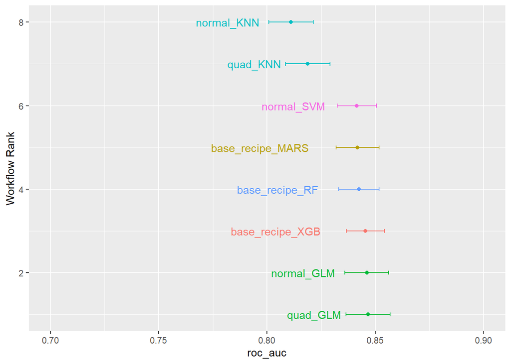

```r
autoplot(
   race_results,
   rank_metric = "roc_auc",
   metric = "roc_auc",
   select_best = TRUE
) +
   geom_text(aes(label = wflow_id), angle = 0, hjust = 1.5) +
   lims(y = c(0.7, 0.9)) +
    coord_flip() +
   theme(legend.position = "none")
```

## Step - 6 Final fit

From here, we could simply choose the best performing model and parameter combination. Instead, we are going to choose 1 model from each of our different recipe types.

To do this, I’ll create a function that will extract the best performing metrics from our grid search and apply those parameters to fit the data on the test set. All we need to do now is decide which models we want and then `map()` them as the first argument into our function. I’ve decided to keep the `quad_GLM`, `base_recipe_XGB`, and the `normal_SVM` models.

```r
select_and_finalize_models <- function(model, metric, data_split, race_results) {
    best_model <-
        race_results %>%
        extract_workflow_set_result(model) %>%
        select_best(metric = metric)

    final_fit <-
        race_results %>%
        extract_workflow(model) %>%
        finalize_workflow(best_model) %>%
        last_fit(split = data_split)
}

final_fit_list <-
    c(
        "quad_GLM",
        "base_recipe_XGB",
        "normal_SVM"
    ) %>%
    set_names() %>%
    map(
        ~ select_and_finalize_models(
            .x,
            "roc_auc",
            churn_split,
            race_results
        )
    )

rm(race_results) # remove the race_results object
```

### Model Performance

We now have 3 finalized model workflows. Here’s how each of them preformed on our test set

```r
final_fit_list %>%
    imap(function(x, name) {
        collect_metrics(x) %>%
            mutate(model = name)
    }) %>%
    bind_rows() %>%
    relocate(model) %>%
    reactable(
        searchable = T,
        wrap = F,
        columns = list(
            .estimate = colDef(format = colFormat(percent = T, digits = 2))
        )
    )
```

| model | .metric | .estimator | .estimate | .config |
| --- | --- | --- | --- | --- |
| quad_GLM | accuracy | binary | 0.812145289443814 | Preprocessor1_Model1 |
| quad_GLM | roc_auc | binary | 0.857465092009141 | Preprocessor1_Model1 |
| base_recipe_XGB | accuracy | binary | 0.808740068104427 | Preprocessor1_Model1 |
| base_recipe_XGB | roc_auc | binary | 0.858982615358195 | Preprocessor1_Model1 |
| normal_SVM | accuracy | binary | 0.81044267877412 | Preprocessor1_Model1 |
| normal_SVM | roc_auc | binary | 0.850921082180742 | Preprocessor1_Model1 |

We can also visualize all of our models together on a Receiver operator curve.

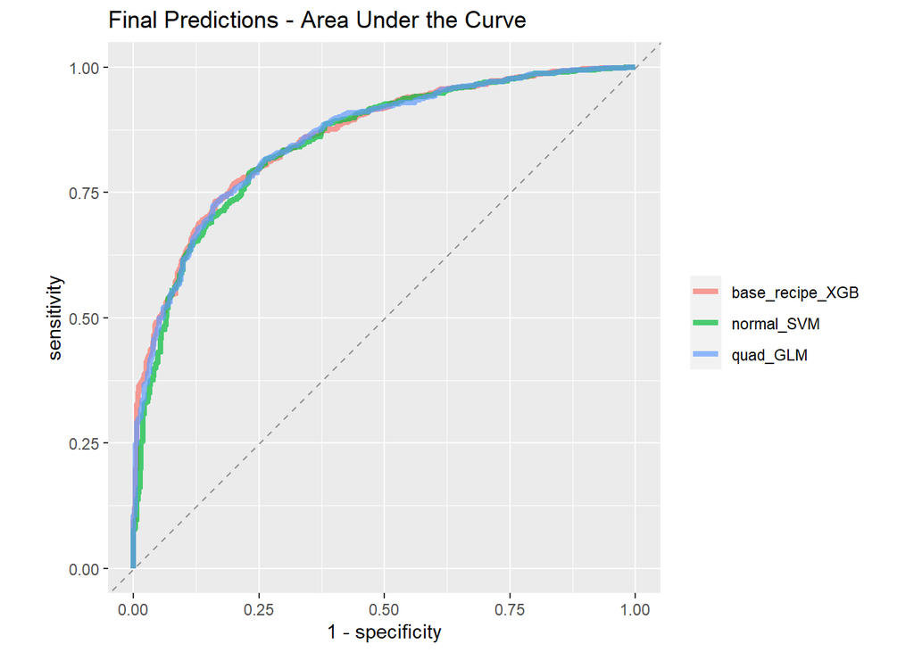

```r
final_fit_list %>%
    imap(function(x, name) {
        collect_predictions(x) %>%
            group_by(id) %>%
            roc_curve(Churn, .pred_No) %>%
            mutate(model = name)
    }) %>%
    bind_rows() %>%
    ggplot(aes(x = 1 - specificity, y = sensitivity, col = model)) +
    geom_abline(slope = 1, color = "gray50", lty = 2, alpha = 0.8) +
    geom_path(size = 1.5, alpha = 0.7) +
    labs(color = NULL) +
    coord_equal() +
    labs(
        title = "Final Predictions - Area Under the Curve"
    )
```

Let’s see how our model preformed with a confusion matrix.

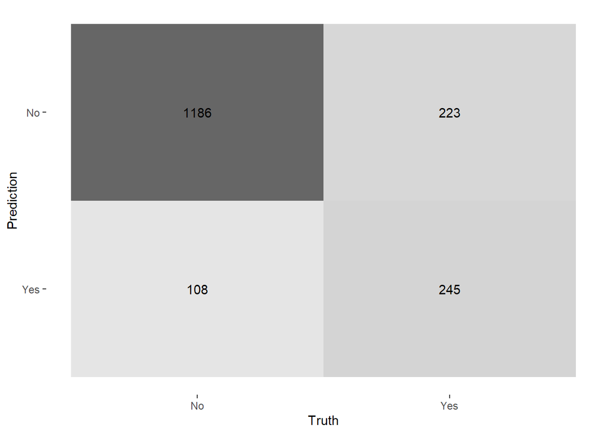

```r
final_fit_list %>%
    pluck('quad_GLM') %>%
    collect_predictions() %>%
    conf_mat(Churn, .pred_class) %>%
    autoplot(type = "heatmap")
```

### Variable Importance

Using the package `vip` we can also gain valuable insight into which variables were most important to our boosted tree model.

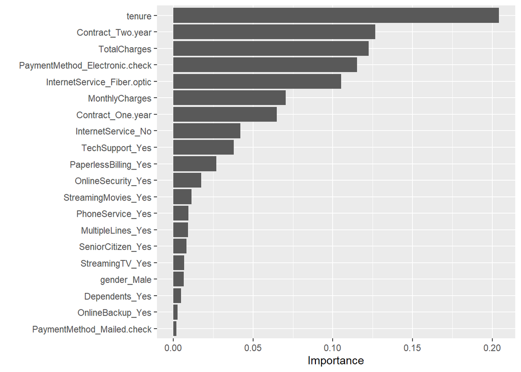

```r
library(vip)

final_fit_list %>%
    pluck('base_recipe_XGB')%>%
    extract_fit_engine() %>%
    vip(20)
```

## Notes

Finally we’ll save these models to be used later in our Shiny application. We’ll write another quick function that `walk()`’s over our `final_fit_list` and uses the model name to create a path for saving the rds file with the `readr` package.

```r
extract_wf_save_rds <- function(model, name) {
    path = str_glue("../app/trained_models/{name}.rds")
    readr::write_rds(extract_workflow(model), path)
}

final_fit_list %>%
    iwalk(extract_wf_save_rds)
```

# Bonus Model

As a bonus step, Let’s try a Dimensional Reduction technique from the package `FactoMineR`. This particular reduction technique is designed for a data set containing both quantitative and qualitative variables.

```r
library(FactoMineR)
library(factoextra)

famd_churn <-
    parsed_data %>%
    select(-customerID, -Churn) %>%
    mutate(
        across(where(is.numeric), ~ as.numeric(scale(.))),
        across(where(is.character), ~ as.factor(.))
    )

res.famd <- FAMD(famd_churn, graph = F)

res.famd
```

```
## *The results are available in the following objects:
##
##   name          description
## 1 "$eig"        "eigenvalues and inertia"
## 2 "$var"        "Results for the variables"
## 3 "$ind"        "results for the individuals"
## 4 "$quali.var"  "Results for the qualitative variables"
## 5 "$quanti.var" "Results for the quantitative variables"
```

Much like our own dimensional reduction analysis earlier, we can use the package `factoextra`’s helper functions to create a Scree plot displaying the variance explained by each dimension.

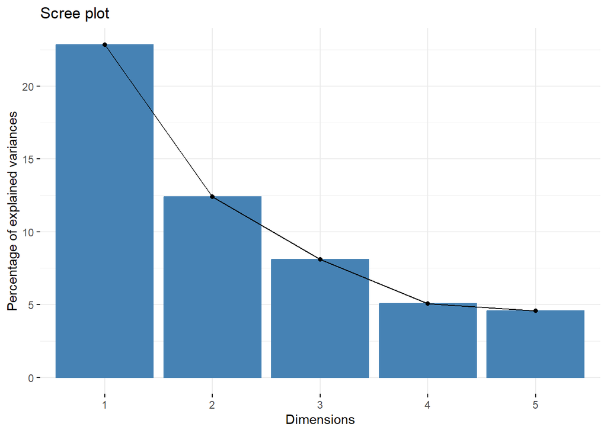

```r
fviz_screeplot(res.famd)
```

4 dimensions seems to be where the constant rate of change levels out. Let’s visualize the variable importance across the first 4 dimensions.

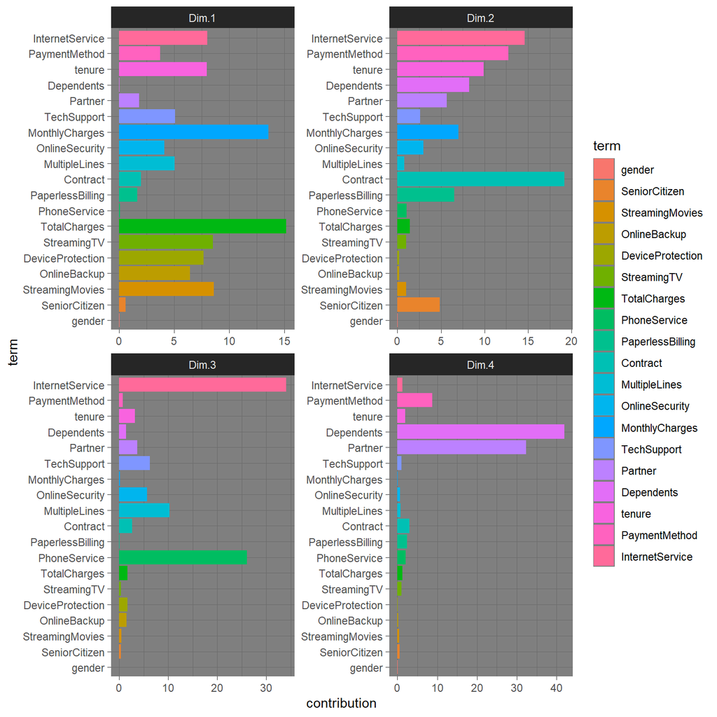

```r
as.data.frame(res.famd$var$contrib[, 1:4]) %>%
    rownames_to_column("term") %>%
    pivot_longer(!term, names_to = "dimension", values_to = "contribution") %>%
    mutate(term = term %>% as.factor() %>% fct_reorder(contribution)) %>%
    ggplot(aes(x = term, y = contribution, fill = term)) +
    geom_bar(stat = "identity") +
    facet_wrap(~ dimension, scales = "free") +
    coord_flip() +
    theme_dark()
```

I can’t help but wonder if we can improve our modeling accuracy using this dimension reduction as a preproccessing step. So let’s try it!

```r
# DIMENSIONALY REDUCED
churn_famd_df <-
    churn_df %>%
    mutate(
        across(where(is.numeric), ~ as.numeric(scale(.)))
    ) %>%
    select(-customerID, -Churn) %>%
    FAMD(., graph = F, ncp = 4) %>%
    get_famd(.) %>%
    pluck('coord') %>%
    as_tibble() %>%
    mutate(
        customerID = pull(churn_df, customerID),
        Churn = pull(churn_df, Churn)
    ) %>%
    rename_with(~gsub("Dim.", "FAMD_", .x, fixed = T))

reactable(
    relocate(churn_famd_df, customerID, Churn) %>%
        head(),
    defaultColDef = colDef(
        format = colFormat(
            digits = 2
        )
    )
)
```

| customerID | Churn | FAMD_1 | FAMD_2 | FAMD_3 | FAMD_4 |
| --- | --- | --- | --- | --- | --- |
| 7590-VHVEG | No | -1.87051656640041 | -0.543451246886499 | 2.77919819671031 | -1.64532914108004 |
| 5575-GNVDE | No | -0.958685251822525 | 1.19600138621334 | 1.48421964473473 | 1.45795522256701 |
| 3668-QPYBK | Yes | -1.69566613293238 | -0.440805684684528 | 1.9370271560397 | 0.590539681593001 |
| 7795-CFOCW | No | -0.117619300548379 | 2.19910585769565 | 3.48023445455983 | 1.33017766008053 |
| 9237-HQITU | Yes | -1.85357974059204 | -2.47375977216109 | 0.044841939911632 | -0.117870411990932 |
| 9305-CDSKC | Yes | 0.923289161409175 | -3.1092150254726 | -0.189022527209454 | -0.164684126790252 |

We’ll use `xgboost` for this last model and preform similar model setup steps as we did before.

```r
set.seed(1234)
churn_famd_split <- initial_split(churn_famd_df, strata = Churn)
churn_famd_train <- training(churn_famd_split)
churn_famd_test <- testing(churn_famd_split)

set.seed(567)
churn_famd_folds <- vfold_cv(churn_famd_train, strata = Churn)

xgb_famd_spec <-
    boost_tree(
        trees = tune(),
        min_n = tune(),
        learn_rate = tune(),
        loss_reduction = tune(),
        sample_size = tune(),
        mtry = tune()
    ) %>%
    set_engine('xgboost') %>%
    set_mode('classification')

famd_recipe <-
    recipe(Churn ~ ., data = churn_famd_train) %>%
    update_role(customerID, new_role = 'id')

xgb_famd_wf <- workflow(famd_recipe, xgb_famd_spec)

xgb_famd_wf
```

```
## ══ Workflow ════════════════════════════════════════════════════════════════════
## Preprocessor: Recipe
## Model: boost_tree()
##
## ── Preprocessor ────────────────────────────────────────────────────────────────
## 0 Recipe Steps
##
## ── Model ───────────────────────────────────────────────────────────────────────
## Boosted Tree Model Specification (classification)
##
## Main Arguments:
##   mtry = tune()
##   trees = tune()
##   min_n = tune()
##   learn_rate = tune()
##   loss_reduction = tune()
##   sample_size = tune()
##
## Computational engine: xgboost
```

time to tune!

```r
doParallel::registerDoParallel()

set.seed(891)

library(finetune)

xgb_famd_rs <- tune_race_anova(
    xgb_famd_wf,
    resamples = churn_famd_folds,
    grid = 20,
    metrics = metric_set(roc_auc),
    control = control_race(verbose_elim = T)
)

collect_metrics(xgb_famd_rs) %>%
    reactable(wrap = F)
```

| mtry | trees | min_n | learn_rate | loss_reduction | sample_size | .metric | .estimator | mean | n | std_err | .config |
| --- | --- | --- | --- | --- | --- | --- | --- | --- | --- | --- | --- |
| 2 | 808 | 9 | 0.00206680762406061 | 1.45913784082131e-07 | 0.54980992761557 | roc_auc | binary | 0.835515170150096 | 10 | 0.00570908755570417 | Preprocessor1_Model04 |
| 2 | 1501 | 15 | 0.00127798506537033 | 5.19482975915464e-06 | 0.559010963391047 | roc_auc | binary | 0.835346221236904 | 10 | 0.00568864132104346 | Preprocessor1_Model05 |
| 2 | 485 | 20 | 0.00170018571384102 | 3.89132453791888e-07 | 0.696606169372099 | roc_auc | binary | 0.835330625450443 | 10 | 0.00562883642623865 | Preprocessor1_Model08 |
| 3 | 266 | 38 | 0.00723259677469767 | 0.00381218475449754 | 0.452990828257753 | roc_auc | binary | 0.835081837077889 | 10 | 0.00558136302904546 | Preprocessor1_Model16 |

plot the racing results

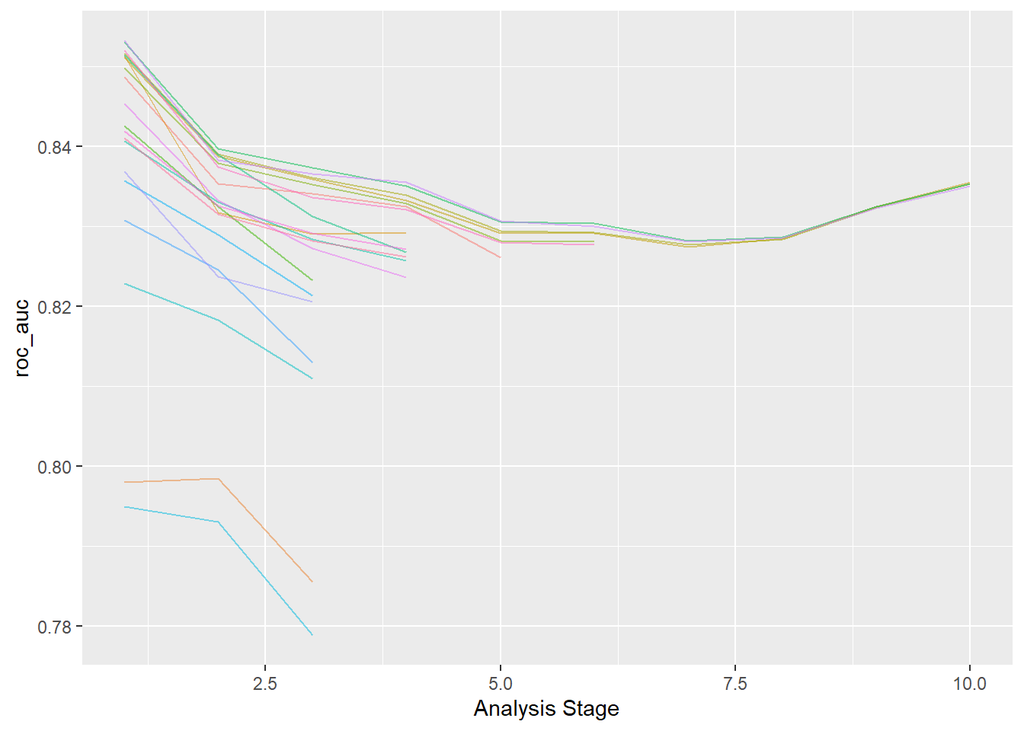

```r
plot_race(xgb_famd_rs)
```

It doesn’t appear we have added anything meaningful to our model by including this reduction. However, it was worth exploring.

```r
xgb_famd_final_fit <- xgb_famd_wf %>%
    finalize_workflow(select_best(xgb_famd_rs, "roc_auc")) %>%
    last_fit(churn_famd_split)

collect_metrics(xgb_famd_final_fit) %>%
    select(-.config) %>%
    reactable()
```

| .metric | .estimator | .estimate |
| --- | --- | --- |
| accuracy | binary | 0.788876276958002 |
| roc_auc | binary | 0.834965620417707 |

Confusion Matrix

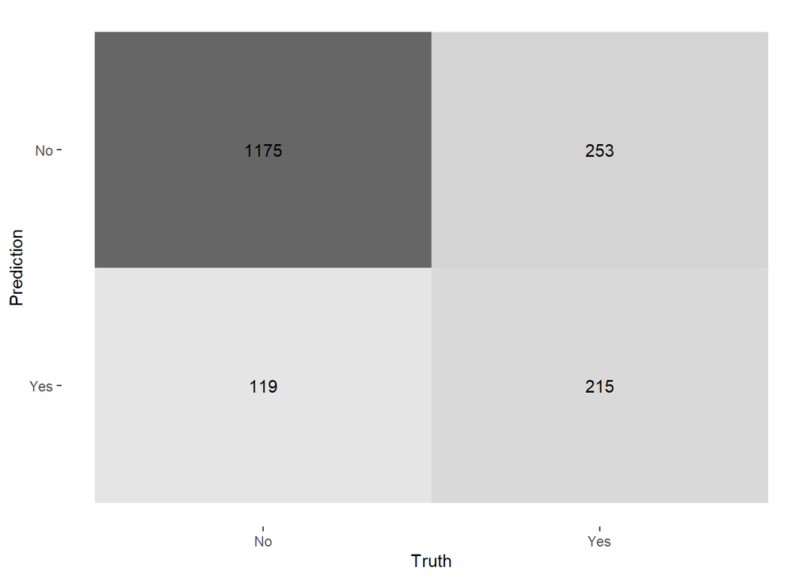

```r
collect_predictions(xgb_famd_final_fit) %>%
    conf_mat(Churn, .pred_class) %>%
    autoplot(type = "heatmap")
```

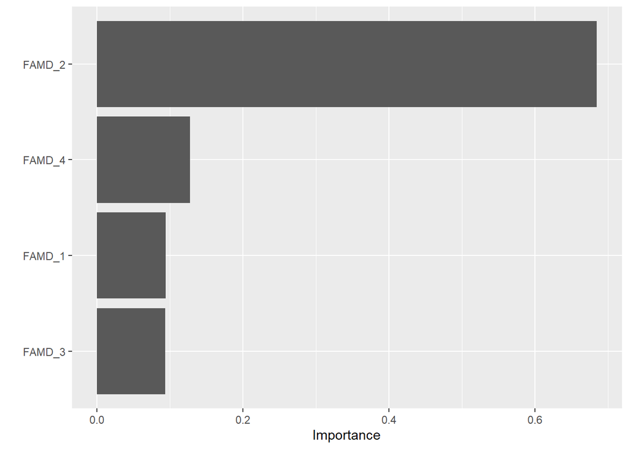

```r
library(vip)

xgb_famd_final_fit %>%
    extract_fit_engine() %>%
    vip()
```